# Practical Machine Learning Project

Riva Malheiros

27 de dezembro de 2015

## Background

Using devices such as Jawbone Up, Nike FuelBand, and Fitbit it is now possible to collect a large amount of data about personal activity relatively inexpensively. These type of devices are part of the quantified self movement – a group of enthusiasts who take measurements about themselves regularly to improve their health, to find patterns in their behavior, or because they are tech geeks. One thing that people regularly do is quantify how much of a particular activity they do, but they rarely quantify how well they do it.

In this project we will use data from accelerometers on the belt, forearm, arm, and dumbell of 6 participants. The goal of your project is to predict the manner in which they did the exercise. This is the “classe” variable in the training set.

## Data Processing

### Load data

The training data for this project are available here:

https://d396qusza40orc.cloudfront.net/predmachlearn/pml-training.csv

The test data are available here:

https://d396qusza40orc.cloudfront.net/predmachlearn/pml-testing.csv

```r
library(utils)
fileurl <- "https://d396qusza40orc.cloudfront.net/predmachlearn/pml-training.csv"
download.file(fileurl, destfile = "pml-training.csv")
fileurl <- "https://d396qusza40orc.cloudfront.net/predmachlearn/pml-testing.csv"
download.file(fileurl, destfile = "pml-testing.csv")

trainset <- read.csv("pml-training.csv", header=TRUE, sep=",", na.strings=c("NA",""))
testset <- read.csv("pml-testing.csv", header=TRUE, sep=",", na.strings=c("NA",""))
```

### Clean up data

We need remove the ID column (X)

```r
trainData <- subset(trainset, TRUE, select = -X)
testData <- subset(testset, TRUE, select = -X)
```

The columns where most of the data are “NA´s” are removed from the dataset

```r
remain <- colSums(!is.na(trainData[,-ncol(trainData)]))/nrow(trainData) >= 0.75
trainData <- trainData[, remain]
testData <- testData[, remain]
```

# Training & Validation dataset

```r
library(caret)
partition = createDataPartition(y=trainData$classe, p=0.75, list=FALSE)
training = trainData[partition,]
validation = trainData[-partition,]
```

## Model

We Will choose a model that provides accuracy greater than 95%

### Train RandomForest model

```r
# load the library
library(randomForest)
set.seed(7)
modelForest <- randomForest(classe~.,data=training)
```

### Validation: RandomForest model

Time to use our model in validation data

```r
prediz <- predict(modelForest,subset(validation, TRUE, select = -classe))

confusionMatrix(prediz,validation$classe)
```

```
## Confusion Matrix and Statistics
##
##           Reference
## Prediction    A    B    C    D    E
##          A 1395    0    0    0    0
##          B    0  949    3    0    0
##          C    0    0  852    3    0
##          D    0    0    0  801    3
##          E    0    0    0    0  898
##
## Overall Statistics
##
##                Accuracy : 0.9982
##                  95% CI : (0.9965, 0.9992)
##     No Information Rate : 0.2845
##     P-Value [Acc > NIR] : < 2.2e-16
##
##                   Kappa : 0.9977
##  Mcnemar's Test P-Value : NA
##
## Statistics by Class:
##
##                      Class: A Class: B Class: C Class: D Class: E
## Sensitivity            1.0000   1.0000   0.9965   0.9963   0.9967
## Specificity            1.0000   0.9992   0.9993   0.9993   1.0000
## Pos Pred Value         1.0000   0.9968   0.9965   0.9963   1.0000
## Neg Pred Value         1.0000   1.0000   0.9993   0.9993   0.9993
## Prevalence             0.2845   0.1935   0.1743   0.1639   0.1837
## Detection Rate         0.2845   0.1935   0.1737   0.1633   0.1831
## Detection Prevalence   0.2845   0.1941   0.1743   0.1639   0.1831
## Balanced Accuracy      1.0000   0.9996   0.9979   0.9978   0.9983
```

When increasing the number of trees reduces the error of the sample but above 200 trees the error stabilizes as we can see in next plot

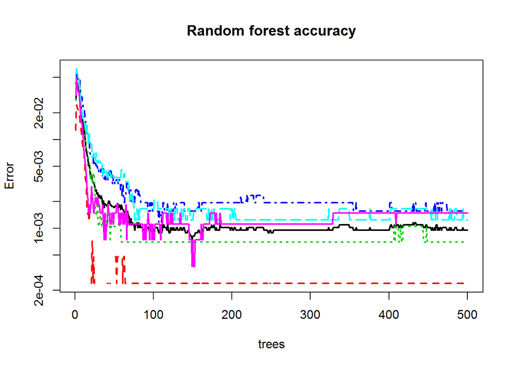

```r
plot(modelForest, log ="y", lwd = 2, main = "Random forest accuracy")
```

# Predict Test set with the RandomForest Model

```r
# Coerce testing dataset to same class and strucuture of training dataset
testData <- rbind(training[100, -ncol(training)] , testData[, -ncol(testData)])
row.names(testData) <- c(100, 1:20)

# Predict
predTest <- predict(modelForest,newdata=testData[-1,])
print(predTest)
```

```
##  1  2  3  4  5  6  7  8  9 10 11 12 13 14 15 16 17 18 19 20
##  B  A  B  A  A  E  D  B  A  A  B  C  B  A  E  E  A  B  B  B
## Levels: A B C D E
```